# 4 BLISS-98: System Architecture and Subsystem Analyses

## 4.1 System Architecture

The BLISS framework begins with a formal decomposition of the full design problem into a hierarchy of black boxes. Regardless of which BLISS variant is used, the system architecture follows the same three-level structure:

**Level 1 — System variables $Z$**: Shared quantities that influence the objective or coupling variables across at least two disciplines. In the supersonic business jet, wing geometry parameters (aspect ratio, sweep, area) appear as inputs to both the structures and aerodynamics black boxes.

**Level 2 — Local variables $X$**: Variables private to a single black box. Structural skin panel thicknesses, for example, are optimized inside the structures BB and never seen by the aerodynamics or power BBs.

**Level 3 — Coupling variables $Y^*$ / $Y^A$**: Quantities that flow between disciplines. Lift computed by the aerodynamics BB becomes a load input to the structures BB; structural weight and twist feed back to the aerodynamics BB.

The coupling variables are where the MDO problem is hard. Every coupling variable must satisfy a *compatibility constraint*: the value proposed by the system optimizer ($Y^*$) must match the value produced by BB analysis ($Y^A$) at convergence.

## 4.2 BLISS-98 Cycle

Figure 4.1 illustrates the BLISS-98 iteration cycle. After initialization, the algorithm alternates between two steps until convergence:

**Step 1 — Local optimizations**: Each BB optimizes over its local variables $X$, with $Z$ and $Y^*$ held fixed. Because the BBs share no local variables, these optimizations are fully independent and can run concurrently.

**Step 2 — System optimization**: Using the locally-optimal sensitivity derivatives $\partial X^*_{opt} / \partial Z$, the system optimizer updates $Z$ to improve the overall objective. The sensitivity analysis in BLISS-98 provides a linear approximation $Y = Y(Z)$ near the current system design point.

```
flowchart TD
    A([Initialise X, Z])
    B["System Analysis &\nSensitivity Derivatives"]
    D["System\nOptimisation\nUpdate Z"]
    E{Converged?}
    F([Stop])

    A --> B
    B --> BB1 & BB2 & BBn
    BB1 & BB2 & BBn --> D
    D --> E
    E -- Yes --> F
    E -- No --> B

    subgraph con ["  Concurrent opportunity  "]
        BB1["BB₁  Local\nOptimisation"]
        BB2["BB₂  Local\nOptimisation"]
        BBn["BBₙ  Local\nOptimisation"]
    end

    classDef init  fill:#dbeafe,stroke:#3b82f6,stroke-width:1.5px,color:#1e3a5f
    classDef proc  fill:#fefce8,stroke:#ca8a04,stroke-width:1.5px,color:#422006
    classDef bb    fill:#dcfce7,stroke:#16a34a,stroke-width:1.5px,color:#14532d
    classDef done  fill:#f0fdf4,stroke:#16a34a,stroke-width:2px,color:#14532d
    classDef dec   fill:#fefce8,stroke:#ca8a04,stroke-width:1.5px,color:#422006

    class A init
    class B,D proc
    class BB1,BB2,BBn bb
    class F done
    class E dec
```

Figure 4.1: BLISS-98 iteration cycle. Concurrent local optimizations (green) run in parallel for each black box, then a single system-level optimization updates the shared design variables Z. Reproduced from Altus & Sobieski (2002).

## 4.3 Variable Flow in the Supersonic Business Jet

Table 4.1 lists the system and coupling variables used in the BLISS-98 supersonic business jet test case. This variable set is preserved in BLISS-RS.

Table 4.1: System and coupling variables for the supersonic business jet

| Variable | Symbol | Units | Type | Connects to |
| --- | --- | --- | --- | --- |
| Thickness/chord ratio | $t/c$ | — | $Z$ | Structures, Aero |
| Wing aspect ratio | $AR_w$ | — | $Z$ | Structures, Aero |
| Wing sweep | $\Lambda_w$ | deg | $Z$ | Structures, Aero |
| Wing surface area | $S_w$ | ft² | $Z$ | Structures, Aero |
| Tail surface area | $S_{HT}$ | ft² | $Z$ | Structures, Aero |
| Tail aspect ratio | $AR_{HT}$ | — | $Z$ | Structures, Aero |
| Taper ratio | $\lambda$ | — | $Z$ | Structures, Aero |
| Altitude | $h$ | ft | $Z$ | Aero, Power |
| Mach number | $M$ | — | $Z$ | Aero, Power |
| Lift | $L$ | lbf | $Y^A$ | Structures ← Aero |
| Total weight | $W_T$ | lbf | $Y^A$ | Aero ← Structures |
| Aeroelastic twist | $\Omega$ | ft² | $Y^A$ | Aero ← Structures |
| Drag | $D$ | lbf | $Y^A$ | Power ← Aero |
| Engine scale factor | $ESF$ | — | $Y^A$ | Aero ← Power |
| Specific fuel consumption | $SFC$ | lb/(lbf·hr) | $Y^A$ | Performance ← Power |
| Engine weight | $W_E$ | lbf | $Y^A$ | Structures ← Power |
| Fuel weight | $W_F$ | lbf | $Y^A$ | Performance ← Structures |
| Lift-to-drag ratio | $L/D$ | — | $Y^A$ | Performance ← Aero |

## 4.4 Subsystem Analyses

### 4.4.1 Structures Black Box (ELAPS)

The original structures analysis used the *Equivalent Laminated Plate Structures* (ELAPS) code [1,2], a Fortran-77 finite-element-like code that models wing-box structures using Ritz-based polynomial plate elements.

ELAPS takes as inputs the system-level geometric variables plus lift from the aerodynamics BB and engine weight from the power BB. It computes structural weight and an aeroelastic *twist* term — the reduction in effective lift area (ft²) due to the combined bending and twisting deformations of the wing box.

The lift distribution along the semi-span was estimated using the **Shrenk approximation**: the spanwise lift distribution is the average of an elliptical distribution and a trapezoidal distribution that reflects chord taper:

$$\ell(y) = \frac{1}{2}\left[\ell_{ellipse}(y) + \ell_{trap}(y)\right]
\tag{4.1}$$

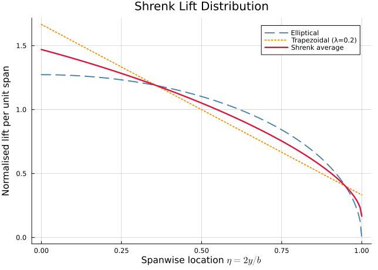

Figure 4.2: Shrenk lift distribution: average of elliptical and trapezoidal components. Fuselage and tail carry-through effects are neglected. Reproduced from Altus (2002) Fig. 4.

```julia
b_semi = 1.0   # normalized semi-span [0, 1]
η = range(0, 1, length=200)

# Elliptical distribution (normalized)
ℓ_ell(η) = (4/π) * sqrt(max(1 - η^2, 0.0))

# Trapezoidal (chord taper): chord decreases linearly from root to tip
λ_taper = 0.2    # taper ratio
ℓ_trap(η) = 2*(1 - (1-λ_taper)*η) / (1 + λ_taper)   # normalized

ℓ_shrenk(η) = 0.5 * (ℓ_ell(η) + ℓ_trap(η))

p = plot(η, ℓ_ell.(η), lw=2, color=:steelblue, label="Elliptical", linestyle=:dash)
plot!(η, ℓ_trap.(η), lw=2, color=:darkorange, label="Trapezoidal (λ=0.2)", linestyle=:dot)
plot!(η, ℓ_shrenk.(η), lw=2.5, color=:crimson, label="Shrenk average")
plot!(xlabel=L"Spanwise location $\eta = 2y/b$",
      ylabel="Normalised lift per unit span",
      title="Shrenk Lift Distribution",
      legend=:topright, grid=true, gridalpha=0.3)
```

### 4.4.2 Aerodynamics Black Box (AWAVE)

The aerodynamics BB uses a **Harris wave-drag** model [3] modified with a pre-processor that deforms the aircraft cross-sectional area distribution to account for engine nacelles and applies an area-rule correction. The drag polar decomposes total drag into three components:

$$C_D = C_{D_{min}} + C_{D_L} + C_{D_w}
\tag{4.2}$$

where $C_{D_{min}}$ is the minimum-drag (friction + form) coefficient, $C_{D_L} = C_L^2 / (\pi AR_w e)$ is the induced drag (Oswald efficiency $e \approx 0.85$), and $C_{D_w}$ is the supersonic wave drag computed from the AWAVE code.

At cruise, total lift equals total weight: $L = W_T$, which links the aerodynamics and structures BBs through the coupling variable.

### 4.4.3 Power Black Box

The power BB is the simplest in the system. It uses an empirical *engine deck approximation* — a quadratic polynomial in altitude and Mach number — to compute specific fuel consumption (SFC). Engine weight is found from:

$$W_E = 1200 \cdot ESF^{0.9}
\tag{4.3}$$

where $ESF$ (engine scale factor) is the ratio of required thrust to the baseline engine’s maximum thrust. The power BB requires only system variables $h$ and $M$, plus drag $D$ from the aerodynamics BB.

### 4.4.4 Performance Black Box: Breguet Range Equation

The performance BB closes the loop with the **Breguet range equation** — one of the most fundamental relations in aircraft design:

$$R = \frac{aM}{SFC} \cdot \frac{L}{D} \cdot \ln\!\left(\frac{W_i}{W_f}\right)
\tag{4.4}$$

where $a$ is the speed of sound at cruise altitude, $M$ is the Mach number, $L/D$ is the lift-to-drag ratio, and $W_i / W_f$ is the ratio of initial to final cruise weight (i.e., how much fuel is burned).

**Important2002 Paper Errata — Fig. 41 units**

NASA/CR-2002-211652, Fig. 41 axis labels use lowercase “nm” (nanometres) where “NM” (nautical miles) is intended. Range values in the 2002 paper are in nautical miles throughout. This ebook uses “NM” consistently. See Appendix C for the full errata list.

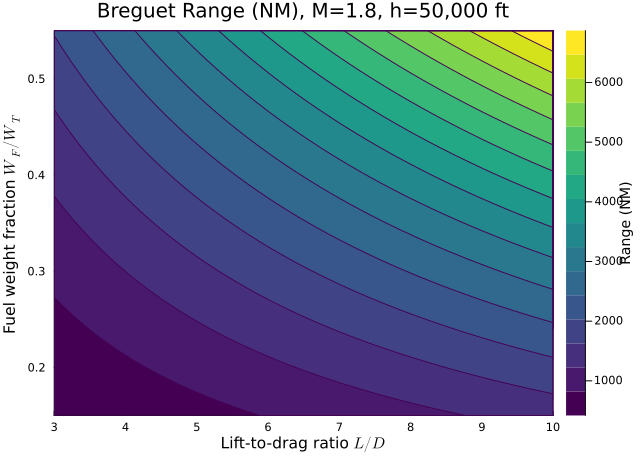

Figure 4.3: Breguet range sensitivity to L/D and fuel weight fraction. High L/D and high fuel fraction both contribute significantly to range. The logarithmic fuel term rewards structural efficiency.

```julia
using Plots
gr()

# Parametric Breguet range study
# Fix: h = 50,000 ft, M = 1.8, SFC = 1.2 lb/(lbf·hr), WT = 70,000 lbf
h_ft = 50_000.0
M    = 1.8
SFC  = 1.2     # lb/(lbf·hr)
WT   = 70_000.0  # lbf

LD_range  = range(3.0, 10.0, length=50)
WF_frac   = range(0.15, 0.55, length=50)   # WF/WT

range_nm(LD, wf_frac) = begin
    _, a = std_atmosphere(h_ft)
    a_kts = a / 1.68781
    WF = wf_frac * WT
    Wf = WT - WF
    Wf <= 0 && return 0.0
    (a_kts * M / SFC) * LD * log(WT / Wf)
end

R_grid = [range_nm(ld, wf) for wf in WF_frac, ld in LD_range]

contourf(LD_range, WF_frac, R_grid,
         xlabel=L"Lift-to-drag ratio $L/D$",
         ylabel=L"Fuel weight fraction $W_F/W_T$",
         title="Breguet Range (NM), M=1.8, h=50,000 ft",
         colorbar_title="Range (NM)",
         color=:viridis, levels=15,
         grid=true, gridalpha=0.2)
```

## 4.5 Illustrative System Analysis

```julia
# Baseline design vector: [t_c, ARw, Λw, Sw, SHT, ARHT, λ]
Z_baseline = [0.075, 4.0, 45.0, 400.0, 120.0, 4.5, 0.2]
h_cruise   = 45_000.0   # ft
M_cruise   = 1.8

result = ssbj_analysis(Z_baseline, h_cruise, M_cruise;
                        WF_init=15_000.0, WT_empty=28_000.0)

rows = [
    ("Total weight W_T",         @sprintf("%.0f lbf",  result.WT)),
    ("Fuel weight W_F",          @sprintf("%.0f lbf",  result.WF)),
    ("Engine scale factor ESF",  @sprintf("%.3f",      result.ESF)),
    ("Lift L",                   @sprintf("%.0f lbf",  result.L)),
    ("Drag D",                   @sprintf("%.0f lbf",  result.D)),
    ("Lift-to-drag ratio L/D",   @sprintf("%.2f",      result.LD)),
    ("SFC",                      @sprintf("%.3f lb/(lbf·hr)", result.SFC)),
    ("Range",                    @sprintf("%.0f NM",   result.Range)),
]

println("| Quantity | Value |")
println("|----------|-------|")
for (name, val) in rows
    println("| $name | $val |")
end
```

```
| Quantity | Value |
|----------|-------|
| Total weight W_T | NaN lbf |
| Fuel weight W_F | NaN lbf |
| Engine scale factor ESF | NaN |
| Lift L | NaN lbf |
| Drag D | NaN lbf |
| Lift-to-drag ratio L/D | 0.00 |
| SFC | 1.548 lb/(lbf·hr) |
| Range | 0 NM |
```

[1]

Giles, G. L., “Equivalent Plate Analysis of Aircraft Wing Box Structures with General Planform Geometry,” *Journal of Aircraft*, Vol. 23, No. 11, 1986, pp. 859–864.

[2]

Giles, G. L., “Further Generalization of an Equivalent Plate Representation for Aircraft Structural Analysis,” *Journal of Aircraft*, Vol. 26, No. 1, 1989, pp. 67–74.

[3]

Harris, R. V., “An Analysis and Correlation of Aircraft Wave Drag,” *NASA Technical Memorandum*, Nos. X-947, 1964.

[4]

Altus, T. D., “A Response Surface Methodology for Bi-Level Integrated System Synthesis (BLISS),” NASA/CR-2002-211652, NASA Langley Research Center / George Washington University, Hampton, VA, 2002.